# Introduction

This analysis is the result of an excercise made in Udacity’s Course: [Exploratory Data Analysis with R](https://www.udacity.com/course/ud651)

The goal is to analyze the Forest Coverage dataset to study the increment in its proportion. The goal is to answer questions like:  
- Which countries have more Forest Coverage?  
- Which countries cares the most about Preserving its Forest Coverage?

### Excercise Instructions: Gapminder Data

The Gapminder website contains over 500 data sets with information about the world’s population. Your task is to download a data set of your choice and create 2-5 plots that make use of the techniques from Lesson 3.

You might use a simple histogram, a boxplot split over a categorical variable, or a frequency polygon. The choice is yours!

[Link to the Gapminder website](http://www.gapminder.org/data/).

Once you’ve completed your investigation, create a post in the discussions that includes:  
1. any questions you answered, your observations, and summary statistics  
2. snippets of code that created the plots  
3. links to the images of your plots

# Data Analysis

#### Load necesary Libraries

```r
library(reshape2)
library(plyr)
library(ggplot2)
library(rworldmap)
library(RColorBrewer)
```

### Download and Cleaning data

```r
setwd("~/Repos/data-analysis-with-r/")
file.path <- "./data/indicator_forest coverage.csv"
data <- read.csv(file.path,col.names = c("Country","1990","2000","2005"))

data <- melt(data, id.vars = c("Country"))
names(data) <- c("Country","Year","Forest.Coverage")

data$Year <- gsub("X","",data$Year)
data$Year <- as.factor(data$Year)

data$Forest.Coverage <- gsub(",",".",data$Forest.Coverage)
data$Forest.Coverage <- as.numeric(data$Forest.Coverage,na.action)

data <- data[complete.cases(data),]
```

### Data Processing

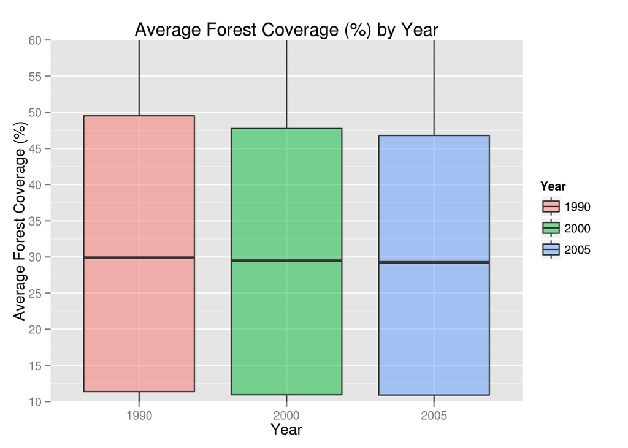

```r
ggplot(data) +
  geom_boxplot(aes(x = Year, y = Forest.Coverage, fill = Year), alpha = 0.5) +
  scale_y_continuous(breaks = seq(0,60,5)) +
  coord_cartesian(ylim = c(10,60)) +
  ylab("Average Forest Coverage (%)") +
  ggtitle("Average Forest Coverage (%) by Year")
```

#### Argentina:

```r
argentina <- subset(data, Country == "Argentina")
argentina
```

```
##       Country Year Forest.Coverage
## 215 Argentina 1990           12.88
## 444 Argentina 2000           12.34
## 673 Argentina 2005           12.07
```

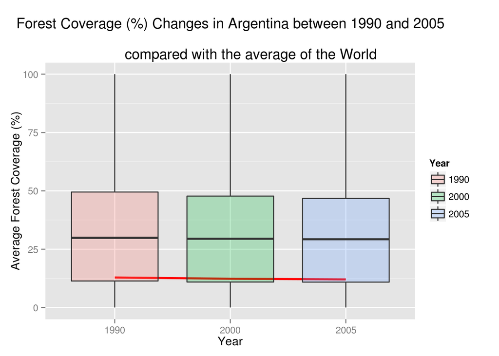

```r
ggplot(argentina) +
  geom_line(aes(x=Year,y=Forest.Coverage, group = Country), stat= "identity",
            size = 1, color = "red") +
  geom_boxplot(data = data , aes(x=Year,y=Forest.Coverage, fill = Year), alpha = 0.25) +
  ggtitle("Forest Coverage (%) Changes in Argentina between 1990 and 2005\n
          compared with the average of the World") +
  ylab("Average Forest Coverage (%)")
```

Argentina’s Forest Coverage went down from 12.88% to 12.07%. Argentina’s values are limiting the First Quantile of the entire population.

#### South America

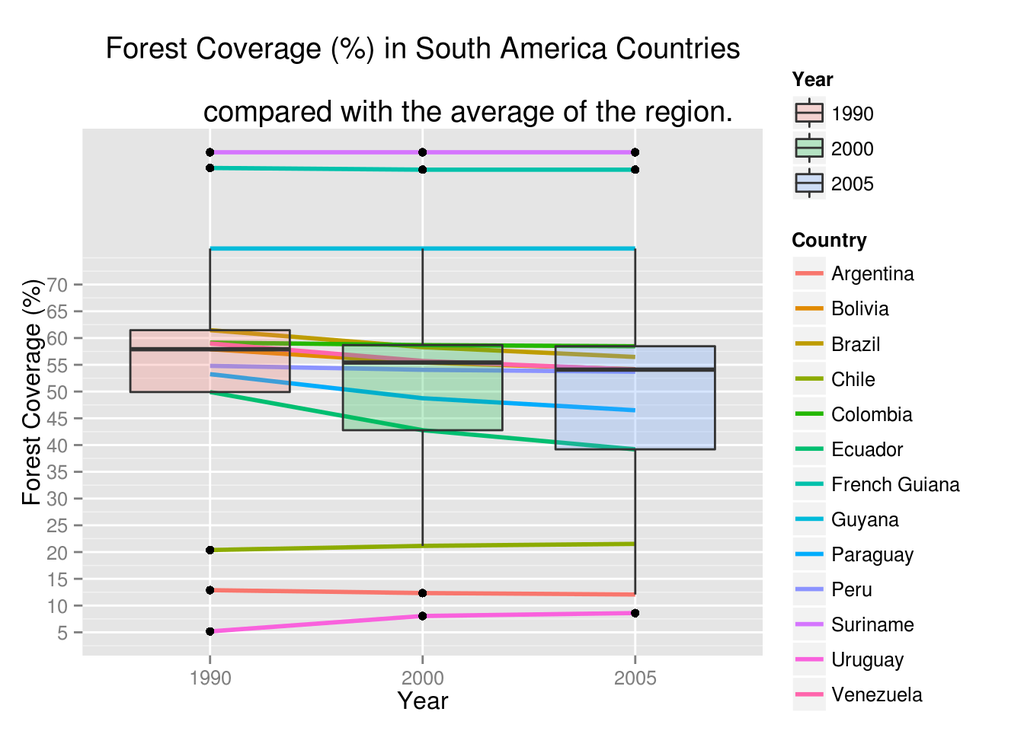

```r
south.america <- c("Argentina", "Chile", "Uruguay", "Paraguay", "Brazil",
                   "Peru", "Ecuador", "Bolivia", "Venezuela", "Colombia",
                   "Suriname", "French Guiana", "Guyana")
south.america.data <- subset(data, Country %in% south.america)

ggplot(south.america.data) +
  geom_line(aes(x=Year,y=Forest.Coverage, group = Country,
                color = Country),
            stat= "identity", size = 1) +
  ggtitle("Forest Coverage (%) in South America Countries\n
           compared with the average of the region.") +
  geom_boxplot(aes(x=Year,y=Forest.Coverage, fill = Year), alpha = 0.25) +
  ylab("Forest Coverage (%)") +
  scale_y_continuous(breaks = seq(0,70,5))
```

#### G20 Countries

I’ve excluded European Union and South Korea due to missing values in the Data Set

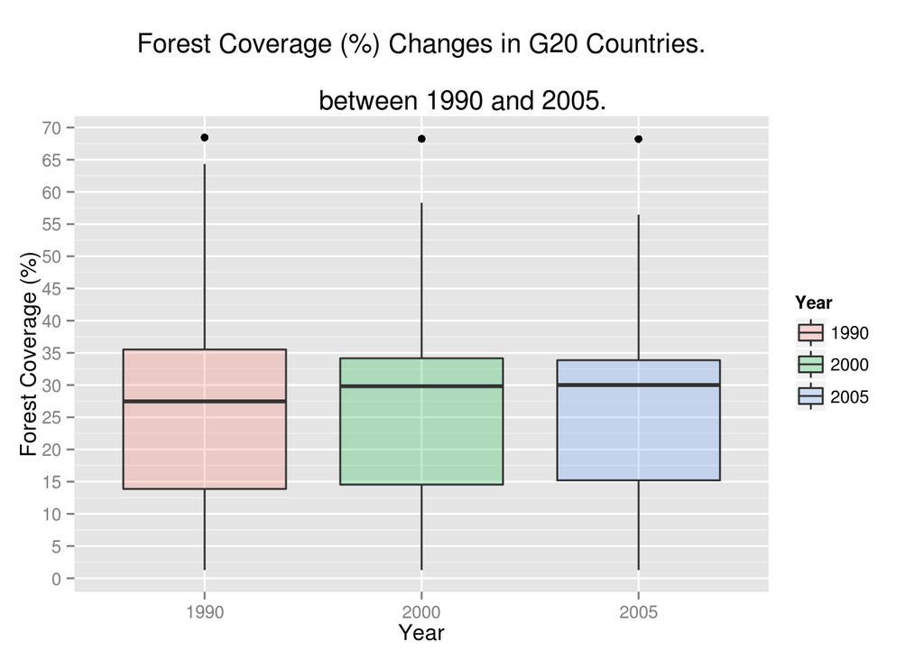

```r
g20 <- c("Argentina","Australia", "Brazil","Canada","China","France",
                   "Germany", "India", "Indonesia","Italy", "Japan","Mexico",
                   "Russia", "Saudi Arabia", "South Africa",
                   "Turkey", "United Kingdom", "United States")
g20.data <- subset(data, Country %in% g20)

ggplot(g20.data) +
  ggtitle("Forest Coverage (%) Changes in G20 Countries.\n
           between 1990 and 2005.") +
  geom_boxplot(aes(x=Year,y=Forest.Coverage, fill = Year), alpha = 0.25) +
  ylab("Forest Coverage (%)") +
  scale_y_continuous(breaks = seq(0,70,5))
```

#### G20 Countries that increased its Forest Coverage

Now I want to calculate the variance in the Forest Coverage in the G20 Countries to determine which ones increased and which ones decreased.

```r
# Calculate de Difference Between FC in 2005 and FC in 1990.
Changes <- subset(g20.data, Year == 2005)$Forest.Coverage - subset(g20.data, Year == 1990)$Forest.Coverage
# Get the list of Countries
Country <- subset(g20.data, Year == 2005)$Country
# Create the Data Frame
g20.Changes <- data.frame(Country, Changes)
# Order the Data Frame by Changes
g20.Changes <- arrange(g20.Changes,Changes,decreasing = TRUE)
# Reset the Factors levels so ggplot can plot in correct order
g20.Changes$Country <- factor(g20.Changes$Country,
                                      levels = g20.Changes$Country)
g20.Changes
```

```
##           Country Changes
## 1           Italy    5.43
## 2           China    4.30
## 3          France    1.84
## 4           India    1.26
## 5  United Kingdom    0.97
## 6         Germany    0.96
## 7          Turkey    0.64
## 8   United States    0.48
## 9    South Africa    0.00
## 10   Saudi Arabia    0.00
## 11         Canada    0.00
## 12         Russia   -0.01
## 13          Japan   -0.23
## 14      Australia   -0.55
## 15      Argentina   -0.81
## 16         Mexico   -2.50
## 17         Brazil   -5.00
## 18      Indonesia  -15.50
```

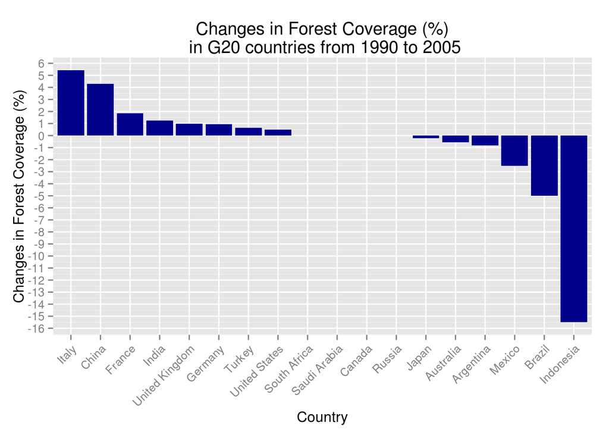

```r
ggplot(g20.Changes) +
  geom_bar(aes(x=Country,y=Changes), fill = "blue4", stat = "identity") +
  scale_y_continuous(breaks = seq(-20,15,1)) +
  ggtitle("Changes in Forest Coverage (%)\n in G20 countries from 1990 to 2005") +
  ylab("Changes in Forest Coverage (%)") +
  theme(axis.text.x = element_text(angle = 45, hjust = 1))
```

Some interesting results:  
- Italy, China, France, India, United Kingdom, Germany, Turkey and United States **increased** their Forest Coverage from 1990 to 2005  
- Japan, Australia, Argentina, Mexico, Brazil, and Indonesia **decreased** their Forest Coverage between 1900 and 2005  
- Wondering about Indonesia? [Deforestation in Indonesia](http://en.wikipedia.org/wiki/Deforestation_in_Indonesia)

#### Top Countries in the World 2005

Which are the Countries in the World with most Forest Coverage?

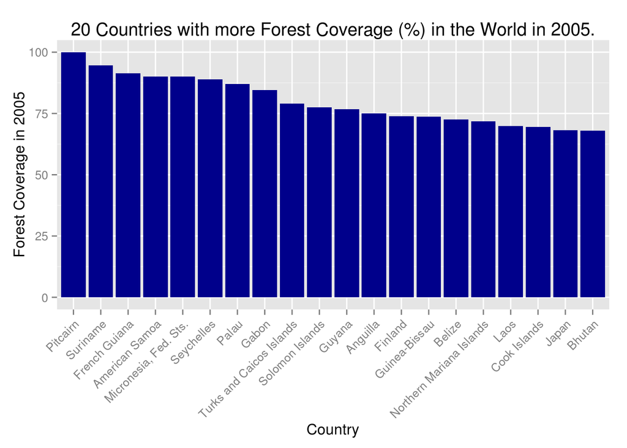

```r
top.countries.2005 <- subset(data, Year == 2005)
top.countries.2005 <- top.countries.2005[order(top.countries.2005$Forest.Coverage,
                                               decreasing = TRUE),]

top.countries.2005$Country <- factor(top.countries.2005$Country,
                                     levels = top.countries.2005$Country)
# Plot Top 20
ggplot(top.countries.2005[1:20,]) +
  geom_bar(aes(x=Country, y = Forest.Coverage), fill = "blue4", stat = "identity") +
  ylab("Forest Coverage in 2005") +
  ggtitle("20 Countries with more Forest Coverage (%) in the World in 2005.") +
  theme(axis.text.x = element_text(angle = 45, hjust = 1))
```

- Learn a little bit more about [Pitcairng](http://en.wikipedia.org/wiki/Pitcairn_Islands)
- Some info about Suriname

Which are the Countries in the World with less Forest Coverage?

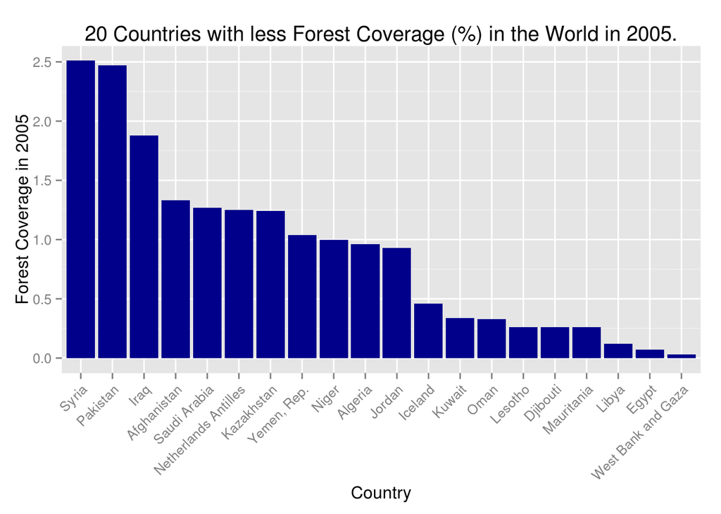

```r
# Plot Top 20
ggplot(tail(top.countries.2005, 20)) +
  geom_bar(aes(x=Country, y = Forest.Coverage), fill = "blue4", stat = "identity") +
  ylab("Forest Coverage in 2005") +
  ggtitle("20 Countries with less Forest Coverage (%) in the World in 2005.") +
  theme(axis.text.x = element_text(angle = 45, hjust = 1))
```

#### Top/Bottom Changes in Forest Coverage in the World

Which countries has increased/decreased its Forest Coverage between 1990 and 2005?

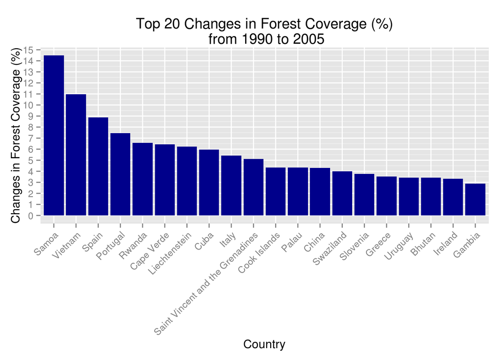

```r
Country <- as.character(unique(data$Country))
Changes <- subset(data, Year == 2005)$Forest.Coverage - subset(data, Year == 1990)$Forest.Coverage

countries.Changes <- data.frame(Country, Changes)
countries.Changes <- arrange(countries.Changes,Changes,decreasing = T)
countries.Changes$Country <- factor(countries.Changes$Country,
                                      levels = countries.Changes$Country)

ggplot(countries.Changes[1:20,]) +
  geom_bar(aes(x=Country,y=Changes), fill = "blue4", stat = "identity") +
  scale_y_continuous(breaks = seq(-11,15,1)) +
  ggtitle("Top 20 Changes in Forest Coverage (%)\n from 1990 to 2005") +
  ylab("Changes in Forest Coverage (%)") +
  theme(axis.text.x = element_text(angle = 45, hjust = 1))
```

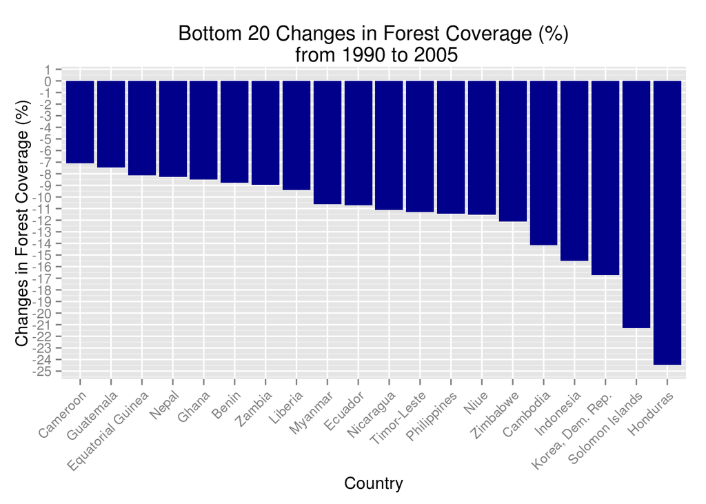

```r
ggplot(tail(countries.Changes, 20)) +
  geom_bar(aes(x=Country,y=Changes), fill = "blue4", stat = "identity") +
  scale_y_continuous(breaks = seq(-25,15,1)) +
  ggtitle("Bottom 20 Changes in Forest Coverage (%)\n from 1990 to 2005") +
  ylab("Changes in Forest Coverage (%)") +
  theme(axis.text.x = element_text(angle = 45, hjust = 1))
```

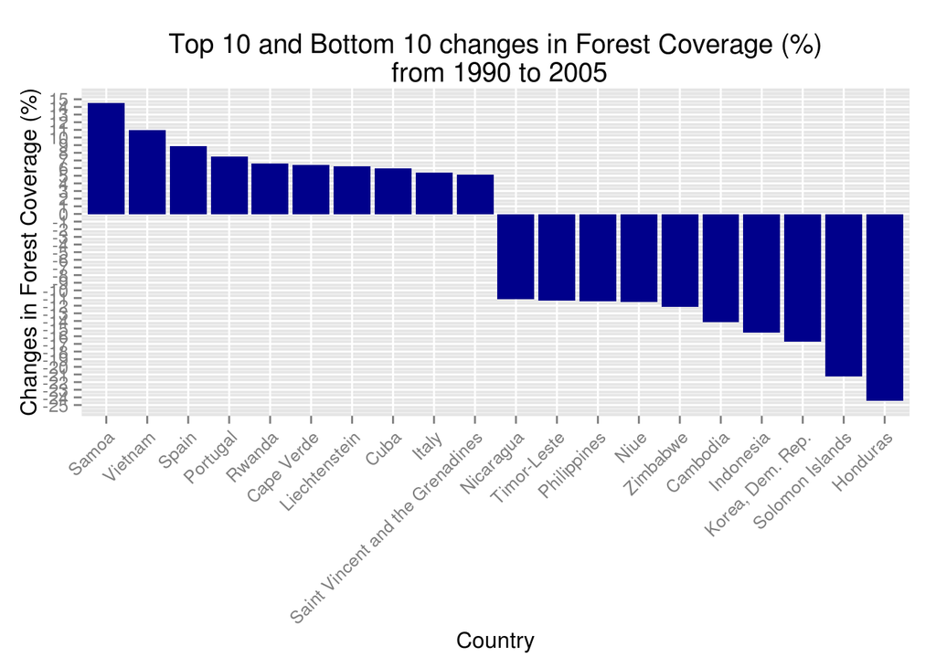

```r
top.bottom <- rbind(countries.Changes[1:10,], tail(countries.Changes, 10))
ggplot(top.bottom) +
  geom_bar(aes(x=Country,y=Changes), fill = "blue4", stat = "identity") +
  scale_y_continuous(breaks = seq(-25,15,1)) +
  ggtitle("Top 10 and Bottom 10 changes in Forest Coverage (%)\n from 1990 to 2005") +
  ylab("Changes in Forest Coverage (%)") +
  theme(axis.text.x = element_text(angle = 45, hjust = 1))
```

- Wow! Honduras has reduced its Forest Coverage by almost a 25%!

#### Fancy World Map Graph

Of course there should be a Fancy World Map with some info. The map show the changes in percent of Forest Coverage between 1990 and 2005

```r
colourPalette <- brewer.pal(7,"RdYlGn")

sPDF <- joinCountryData2Map( countries.Changes, joinCode = "NAME",
                             nameJoinColumn = "Country")
```

```
## 201 codes from your data successfully matched countries in the map
## 13 codes from your data failed to match with a country code in the map
## 43 codes from the map weren't represented in your data
```

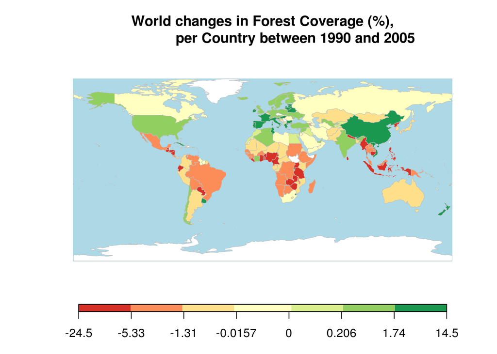

```r
mapParams <- mapCountryData( sPDF, nameColumnToPlot="Changes",
                colourPalette = colourPalette,
                mapTitle = "World changes in Forest Coverage (%),
                per Country between 1990 and 2005",
                oceanCol = "lightblue",
                missingCountryCol = "white",
                addLegend = FALSE)
do.call( addMapLegend
 , c(mapParams
 , legendLabels="all"
 , legendWidth=0.5 ))
```